# Practical: predicting species richness

Physalia workshop on GLLVMs

Bert van der Veen

# Background

In this practical we use a multispecies model to predict species richness. The key ideas from the lecture are:

- Species richness is an emergent property of the joint species model
- The correct distribution for species richness is the Poisson-Binomial
- `predictSR()` computes expected richness from any fitted `gllvm` model, for any response distribution
- A missing nonlinear term in the fixed effects can be silently absorbed by the latent variables, so the usual conditional diagnostics look fine even when richness predictions for new sites are biased

We use two datasets. Part I and Part III use the alpine plant data (binary presence-absence, elevation gradient) that we have used before. Part II uses the carabid beetle data (counts, already used in Practicals 1 and 3) to check whether the lack-of-fit problem demonstrated in the lecture also shows up elsewhere.

```r
library(gllvm)
TMB::openmp(parallel::detectCores()-1, autopar = TRUE, DLL = "gllvm")
```

```
## gllvm
##    11
## attr(,"autopar")
## [1] TRUE
```

```r
Y <- read.csv("../../data/alpineY.csv")[,-1]
X <- read.csv("../../data/alpineX.csv")[,-1]
X <- X[rowSums(Y) > 0, ]
Y <- Y[rowSums(Y) > 0, ]
X_sc <- data.frame(scale(X[, sapply(X, is.numeric)]))
```

# Part I: Fitting a model and predicting richness

We start by fitting a model with elevation as a covariate and two latent variables.

```r
model1 <- gllvm(y = Y, X = X_sc,
                formula = ~ELEV,
                num.lv = 2,
                family = "binomial",
                seed = 1)
```

Check residuals from the Poisson-Binomial distribution:

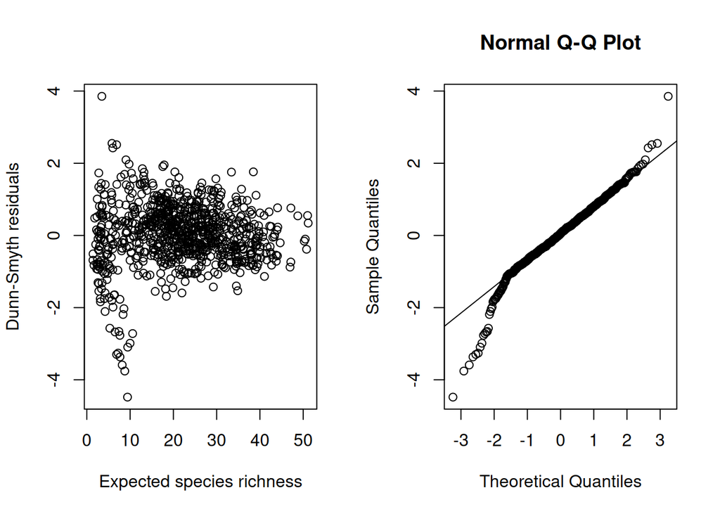

```r
sr <- predictSR(model1, se.fit = FALSE)
plot(sr, model1)
```

Now predict species richness along the elevation gradient:

```r
elev_seq <- seq(min(X_sc$ELEV), max(X_sc$ELEV), length.out = 100)
newX <- data.frame(ELEV = elev_seq)

srNew <- predictSR(model1, newX = newX, level = 0)
```

Plot observed richness against predicted richness:

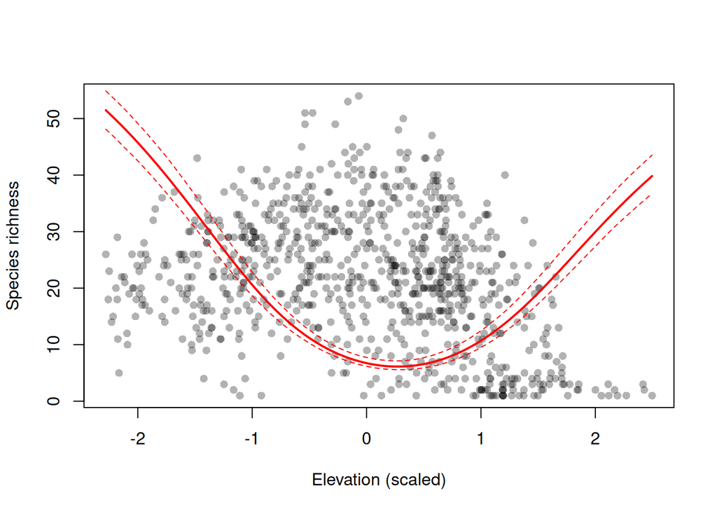

```r
obs_sr <- rowSums(Y)
plot(X_sc$ELEV, obs_sr, pch = 16, col = rgb(0,0,0,0.3),
     xlab = "Elevation (scaled)", ylab = "Species richness")
lines(elev_seq, srNew$expected$fit, col = "red", lwd = 2)
lines(elev_seq, srNew$expected$lower, col = "red", lwd = 1, lty = 2)
lines(elev_seq, srNew$expected$upper, col = "red", lwd = 1, lty = 2)
```

## Tasks I

1. Fit the model and predict species richness as above. Does the model capture the observed richness pattern well?
2. Add more covariates (e.g., `SLOPE`, `MIND`, `SOLRAD`) and see if the richness prediction improves.
3. Change the number of latent variables (0, 1, 2, 3). How does this affect the richness prediction?
4. Use `AIC()` or `BIC()` to compare models. Does including latent variables improve fit?
5. Examine the `predictSR` residuals: do they look like random noise, or is there remaining structure?

# Part II: Diagnosing and fixing lack of fit

In the lecture, the alpine example showed that a missing quadratic elevation term can be absorbed entirely by the latent variables: `plot(model)` and the usual conditional residuals look clean, but predictions for a *new* site (latent variables set to zero, since there is no estimated score for it) are biased, and only the marginal Poisson-Binomial residuals reveal the problem.

We reproduce that same diagnostic here, but on the carabid beetle data instead of the alpine data, using soil moisture (`Moist`) as the covariate instead of elevation.

```r
Yb <- t(read.csv("../../data/beetlesY.csv"))
colnames(Yb) <- Yb[2, ]
Yb <- Yb[-c(1:2), -c(1, 70:71)]
Yb <- as.data.frame(apply(Yb, 2, as.integer))

Xb <- read.csv("../../data/beetlesX.csv")[, -c(1:5)]
Xb <- as.data.frame(apply(Xb, 2, as.numeric))
Xb_sc <- data.frame(scale(Xb[, c("Moist", "Elevation")]))
```

```r
modelB_lin <- gllvm(y = Yb, X = Xb_sc,
                    formula = ~Moist,
                    num.lv = 2,
                    family = "negative.binomial",
                    seed = 1)
```

Predict richness twice: once “conditionally”, using the model’s own estimated site scores (the default, `level = 1`), and once “marginally”, forcing the latent variables to zero as if predicting for a new site.

```r
sr_full <- predictSR(modelB_lin, se.fit = FALSE)
sr_marg <- predictSR(modelB_lin, se.fit = FALSE,
                     newLV = matrix(0, ncol = 2, nrow = nrow(Yb)))

res_full <- residuals(sr_full, modelB_lin)
res_marg <- residuals(sr_marg, modelB_lin)
```

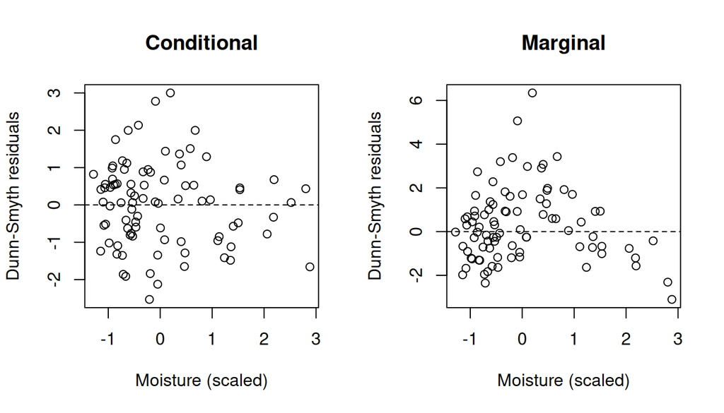

```r
par(mfrow = c(1, 2))
plot(Xb_sc$Moist, res_full$residuals, xlab = "Moisture (scaled)",
     ylab = "Dunn-Smyth residuals", main = "Conditional")
abline(h = 0, lty = 2)
plot(Xb_sc$Moist, res_marg$residuals, xlab = "Moisture (scaled)",
     ylab = "Dunn-Smyth residuals", main = "Marginal")
abline(h = 0, lty = 2)
```

## Tasks II

1. Look at the two residual-vs-moisture panels above. Which one shows a clear pattern, and which looks flat? What does that tell you about where the missing nonlinearity has gone?
2. Refit the model with `formula = ~Moist + I(Moist^2)` and repeat the marginal residual check. Does the pattern disappear?
3. Why does `plot(modelB_lin)` (the default conditional diagnostic) not warn you about this problem, even though the fixed-effect part of the model is mis-specified?
4. This matters most when predicting richness for a site that was not part of the fitted data, so there is no estimated latent variable to lean on. Using `newX` with a sequence of `Moist` values and `newLV = matrix(0, ...)`, compare the richness curve predicted by the linear model to the one predicted by the quadratic model. How different are they?
5. Is there another covariate, in the beetle data or in the alpine data from Part I, where you suspect the same problem could occur? How would you check?

# Part III: Exploring the Poisson-Binomial

To understand why univariate species richness analysis can be misleading, compare the predicted distribution of species richness from your model to what a Poisson regression would give.

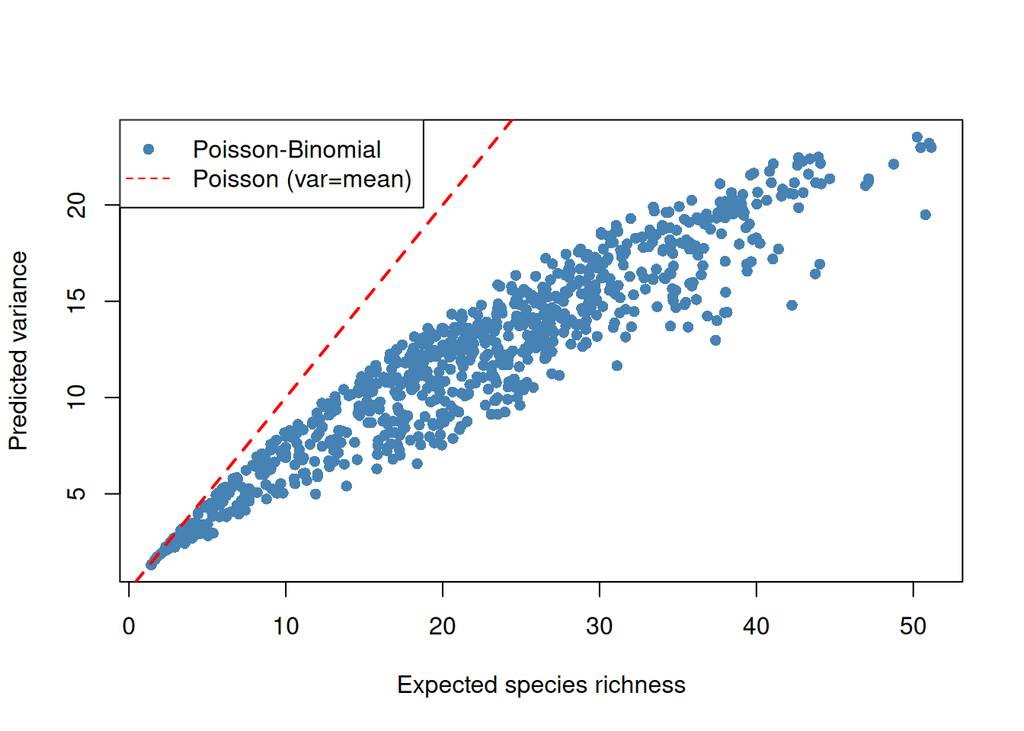

```r
# Expected richness and variance from the model
pred_probs <- predict(model1, type = "response") # n x m matrix
exp_sr <- rowSums(pred_probs)        # Poisson-Binomial mean
var_sr <- rowSums(pred_probs * (1 - pred_probs))  # PB variance

# Compare to Poisson assumption
plot(exp_sr, var_sr, xlab = "Expected species richness",
     ylab = "Predicted variance", pch = 16, col = "steelblue")
abline(0, 1, col = "red", lty = 2, lwd = 2)  # Poisson: var = mean
legend("topleft", legend = c("Poisson-Binomial", "Poisson (var=mean)"),
       pch = c(16, NA), lty = c(NA, 2), col = c("steelblue", "red"))
```

## Tasks III

1. Run the code above. Is the Poisson assumption (variance = mean) realistic for these data?
2. When variance < mean (underdispersion), what does that imply ecologically?
3. Subset the data to a low-diversity region (e.g., high elevation). How does the Poisson approximation perform there versus a diverse region?